# Loops, Across, and Conditionals

Kene David Nwosu

Sabina Rodriguez Velasquez

2024-11-18

# 1 Introduction

At the heart of many programming tasks is the concept of repeating a task multiple times. A `for` loop in R allows us to do just that. Loops enable efficient repetition, saving time and effort.

Whether you’re a beginner or an experienced coder, mastering these concepts is essential for writing intelligent R code.

Let’s dive in and enhance your coding skills!

# 2 Learning Objectives

## 2.1 Packages

‣ We will use multiple packages in this lesson

‣ **Ensure the following packages are installed and loaded:**

```r
# Load necessary packages
if(!require(pacman)) install.packages("pacman")
pacman::p_load(tidyverse, here, openxlsx, tools, outbreaks, medicaldata)
```

## 2.2 Intro to `for` Loops

‣ Let’s start with a simple example of using `for` loops in R

‣ Suppose we have a **vector of children’s ages** and want to **convert these to months**

‣ First, create a vector of ages in years

```r
ages <- c(7, 8, 9)                        # ages 7 8 and 9
```

‣ We could easily convert ages to months using `*` operation in R

```r
ages * 12
```

```
## [1]  84  96 108
```

‣ What R is doing (conceptually) though is running a for loop. Let’s write it out explicitly

```r
for (age in ages) print(age * 12)
```

```
## [1] 84
## [1] 96
## [1] 108
```

‣ `age` is a temporary variable that takes each element in `ages`

‣ You can choose **any name** for this variable

```r
for (random_name in ages) print(random_name * 12)  # random_name
```

```
## [1] 84
## [1] 96
## [1] 108
```

‣ If the loop’s content is **more than one line**, use **curly brackets** `{}`

```r
for (age in ages) {   # multiple line loop
  age_months <- age * 12
  print(age_months)
}
```

```
## [1] 84
## [1] 96
## [1] 108
```

‣ The general structure of any `for` loop:

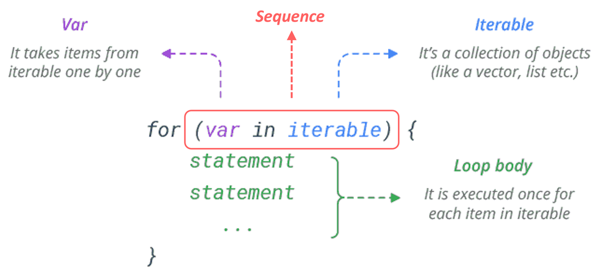

*(NOTE: Answers are at the bottom of the page. Try to answer the questions yourself before checking.)*

### Hours to Minutes Basic Loop

Try converting hours to minutes using a `for` loop. Start with this vector of hours:

```r
hours <- c(3, 4, 5) # Vector of hours
# Your code here

for (hour in hours) {
  minutes <- hour * 60
  print(minutes) # convert hours to minutes and print(minutes)
}
```

‣ Side-note: Loops can be nested within each other. For instance:

```r
# for i in 1:2, for j in 1:2, print i * j
for (i in 1:2) {
  for (j in 1:2) {
    print(i * j)
  }
}
```

```
## [1] 1
## [1] 2
## [1] 2
## [1] 4
```

‣ This creates a combination of `i` and `j` values as shown in this table:

| i | j | i * j |
| --- | --- | --- |
| 1 | 1 | 1 |
| 1 | 2 | 2 |
| 2 | 1 | 2 |
| 2 | 2 | 4 |

‣ Nested loops are less common though, and often have more efficient alternatives.

# 3 Are `for` Loops Useful in R?

‣ R already has *vectorized* operations!

‣ Example: Age conversion without a loop. (Does not work by default in most programming languages)

```r
# ages * 12
ages * 12
```

```
## [1]  84  96 108
```

‣ Moreover, usually working with data frames and `tidyverse` operations:

```r
ages_df <- tibble(age = ages)
# mutate ages_df to add age_months column
ages_df %>%
  mutate(age_months = age * 12)
```

```
## # A tibble: 3 × 2
##     age age_months
##   <dbl>      <dbl>
## 1     7         84
## 2     8         96
## 3     9        108
```

‣ Loops will be quite useful in specific scenarios:

- operations on multiple data frames
- working with non-dataframe objects (e.g. plots)

‣ **Loops vs function mapping?**

‣ Often, loop tasks can be replaced with custom functions which are then mapped across a vector or data frame.

‣ But loops are easy to learn, think about and debug, even for beginners.

## 3.1 Looping with an Index

‣ Often useful to loop through a vector using an index, which is a counter for the current iteration.

‣ Example: converting ages in years to months using an index:

```r
# Recall:
ages <- c(7, 8, 9) # Vector of ages
```

‣ Create a sequence of indices the same length as the ages vector:

```r
1:length(ages) # 1 to the length of ages
```

```
## [1] 1 2 3
```

```r
indices <- 1:length(ages) # then assign to object called indices
```

‣ Use the index in a `for` loop to convert each age to months:

```r
# for i in indices, print ages[i] * 12
for (i in indices) print(ages[i] * 12)
```

```
## [1] 84
## [1] 96
## [1] 108
```

‣ The variable name in the loop (e.g., `i`, `j`, `index`) is arbitrary.

‣ Of course, index-based loops can be used directly without a separate variable:

```r
# for i in 1:length(ages), print ages[i] * 12
for (i in 1:length(ages)) print(ages[i] * 12)
```

```
## [1] 84
## [1] 96
## [1] 108
```

‣ Such indexed loops will be helpful for working with multiple vectors simultaneously.

### Hours to Minutes Indexed Loop

Rewrite your loop from last question using indices:

```r
hours <- c(3, 4, 5) # Vector of hours

# Your code here

for (i in 1:length(hours)) {
  print(hours[i] * 60)
}
```

‣ Side-note: The function `seq_along()` is a shortcut for creating a sequence of indices.

‣ Equivalent to `1:length()`:

```r
# These two are equivalent ways to generate sequence of indices for `ages`
1:length(ages)
```

```
## [1] 1 2 3
```

```r
seq_along(ages)
```

```
## [1] 1 2 3
```

# 4 Looping on Multiple Vectors

‣ Looping with indices allows us to work with multiple vectors simultaneously.

```r
# Consider:
ages <- c(7, 8, 9) # ages in years
heights <- c(120, 130, 140) # heights in cm
```

‣ We can loop through both using the index method:

```r
# for i in 1:length(ages), print a pasted string with age and height

for(i in 1:length(ages)) {
  age <- ages[i]
  height <- heights[i]
  print(paste("Age:", age, "Height:", height))
}
```

```
## [1] "Age: 7 Height: 120"
## [1] "Age: 8 Height: 130"
## [1] "Age: 9 Height: 140"
```

‣ In each iteration:

- `i` is the index.
- We extract the ith element from each vector
- We paste the two together
- We print the result

Alternatively, we can skip the variable assignment and use the indices in the `print()` statement directly:

```r
for(i in 1:length(ages)) {
  print(paste("Age:", ages[i], "Height:", heights[i]))
}
```

```
## [1] "Age: 7 Height: 120"
## [1] "Age: 8 Height: 130"
## [1] "Age: 9 Height: 140"
```

### BMI Calculation Loop

Using a for loop, calculate the Body Mass Index (BMI) of the three individuals shown below. The formul for BMI is `BMI = weight / (height ^ 2)`.

```r
weights <- c(30, 32, 35) # Weights in kg
heights <- c(1.2, 1.3, 1.4) # Heights in meters

for(i in 1:length(weights)) {
  weight <- weights[i]
  height <- heights[i]
  bmi <- weight/(height^2)
  print(paste("Weight:", weight,
              "Height:", height,
              "BMI:", bmi
  ))
  }
```

## 4.1 Storing Loop Results

‣ Usually we want to store loop results rather than just printing.

‣ Example: converting ages to months.

```r
# Recall this loop:
ages <- c(7, 8, 9) # Vector of ages
for(i in 1:length(ages)) {
  print(ages[i] * 12)
}
```

```
## [1] 84
## [1] 96
## [1] 108
```

‣ Let’s try to store this info in a vector.

‣ Create an empty vector to store results.

```r
ages_months <- vector(mode = "numeric", length = length(ages)) # vector of mode "numeric" and length 3

ages_months
```

```
## [1] 0 0 0
```

‣ How do we store values in this vector?

```r
ages_months[1] <- 99                     # Store 99 in the first element of ages_months
ages_months[2] <- 100                      # Store 100 in the second element of ages_months

ages_months
```

```
## [1]  99 100   0
```

‣ Now, let’s execute the loop, storing the results in `ages_months`:

```r
 ages_months <-  vector("numeric", length(ages))             # Create `age_months` vector of mode "numeric" and length of ages

for (i in 1:length(ages)){
  ages_months[i] <- ages[i] * 12
}              # for i in 1:length(ages)
              # store ages[i] * 12 in ages_months[i]
ages_months
```

```
## [1]  84  96 108
```

### Height cm to m

Use a for loop to convert height measurements from cm to m. Store the results in a vector called `height_meters`.

```r
height_cm <- c(180, 170, 190, 160, 150) # Heights in cm

height_m <- vector("numeric", length(height_cm)) # numeric vector of same length as height_cm

for (i in 1:length(height_cm)) {
  height_m[i] <- height_cm[i]/100
}

height_m
```

‣ Watch out! Create your empty object **outside** the loop to save all iteration results.

```r
# Consider this:
ages <- c(7, 8, 9)

for (i in 1:length(ages)) {
  ages_months <- vector("numeric", length(ages))
  ages_months[i] <- ages[i] * 12
}
ages_months
```

```
## [1]   0   0 108
```

‣ Do you see the problem?

‣ Side Note. In a rush? Initialize your vector with `c()` and append values:

```r
ages <- c(7, 8, 9)
ages_months <- c() # quick and dirty way to initialize vector

for (i in 1:length(ages)) {
  ages_months[i] <- ages[i] * 12
}
ages_months
```

```
## [1]  84  96 108
```

‣ And, you can append values at the end of the vector using `c()`:

```r
# Redo loop, but append values to end of vector with c()
ages <- c(7, 8, 9)
ages_months <- c() # quick and dirty way to initialize vector

for (i in 1:length(ages)) {
  ages_months <- c(ages_months, ages[i]*12)
}
ages_months
```

```
## [1]  84  96 108
```

```r
number <- 9
number
```

```
## [1] 9
```

```r
number <- c(number, 10)
number
```

```
## [1]  9 10
```

‣ Discouraged because R does not know the final length of the vector, so reallocates memory each time you append a value.

‣ Slow performance with large vectors. But for quick analysis, it’s fine.

# 5 If Statements in Loops

‣ `If` statements can be integrated into loops in R.

‣ Example: Classifying ages as “Child” if under 18.

```r
age_vec <- c(2, 12, 17, 24, 60) # Vector of ages

# for age in ages, if age < 18, print "Child"
for (age in age_vec){
  if (age < 18) {
    print("Child")
  }
}
```

```
## [1] "Child"
## [1] "Child"
## [1] "Child"
```

‣ Use curly braces for clarity and adding more code.

```r
age_vec <- c(2, 12, 17, 24, 60) # Vector of ages

# for age in ages, if age < 18, print "Child"
for (age in age_vec){
  if (age < 18) {
    print("Processing:") # put these in loop:
    print(paste("Child, Age", age ))
  }
}
```

```
## [1] "Processing:"
## [1] "Child, Age 2"
## [1] "Processing:"
## [1] "Child, Age 12"
## [1] "Processing:"
## [1] "Child, Age 17"
```

‣ Let’s add another condition with `else if` as ‘Child’ or ‘Teen’ based on age.

```r
# Add else if age >= 13 && age < 18, print "Teen"
for (age in age_vec) {
  if (age < 13) {
    print(paste("Child, Age", age))
  } else if (age >= 13 && age < 18){
      print(paste("Teen, Age", age))
    }
}
```

```
## [1] "Child, Age 2"
## [1] "Child, Age 12"
## [1] "Teen, Age 17"
```

‣ Final `else` statement for other ages, classifying as ‘Adult’.

```r
# Add final else statement for "Adult"
for (age in age_vec) {
  if (age < 13) {
    print(paste("Child, Age", age))
  } else if (age >= 13 && age < 18){
      print(paste("Teen, Age", age))
  } else {
      print(paste("Adult, Age", age))
    }
}
```

```
## [1] "Child, Age 2"
## [1] "Child, Age 12"
## [1] "Teen, Age 17"
## [1] "Adult, Age 24"
## [1] "Adult, Age 60"
```

‣ We can store these classifications in a vector using index-based loop.

```r
age_class <- vector("character", length(age_vec))  # vector of mode "character" and length of age_vec

# Refactor loop from above to store classifications in age_class
for (i in 1:length(age_vec)) {
  if (age_vec[i] < 13) {
    age_class[i] <- paste("Child, Age", age_vec[i])
  } else if (age_vec[i] >= 13 && age_vec[i] < 18){
     age_class[i] <- paste("Teen, Age", age_vec[i])
  } else {
      age_class[i] <- paste("Adult, Age", age_vec[i])
    }
}

age_class
```

```
## [1] "Child, Age 2"  "Child, Age 12" "Teen, Age 17"  "Adult, Age 24"
## [5] "Adult, Age 60"
```

### Temperature Classification

You have a vector of body temperatures in Celsius. Classify each temperature as ‘Hypothermia’, ‘Normal’, or ‘Fever’ using a `for` loop combined with `if` and `else` statements.

Use these rules:

- Below 36.0°C: ‘Hypothermia’
- Between 36.0°C and 37.5°C: ‘Normal’
- Above 37.5°C: ‘Fever’

```r
body_temps <- c(35, 36.5, 37, 38, 39.5) # Body temperatures in Celsius
classif_vec <- vector("character", length(body_temps)) # character vec, length of body_temps

for (i in 1:length(body_temps)) {
    # Add your if-else logic here
    if (body_temps[i] < 36.0) {
        classif_vec[i] <- paste(body_temps[i], "°C is Hypothermia")
    }
  else if (body_temps[i] >= 36.5 && body_temps[i] <= 37.5 ) {
    classif_vec[i] <- paste(body_temps[i], "°C is Normal")
  }
  else {
    classif_vec[i] <- paste(body_temps[i], "°C is Fever")
  }
    ## add other conditions and their corresponding classifications
}

classif_vec
```

An expected output is below

```
35°C is Hypothermia
36.5°C is Normal
37°C is Normal
38°C is Fever
39.5°C is Fever
```

# 6 Real Loops Application: Generating Multiple Plots

‣ Using loops to **generate multiple plots** for different groups within a dataset.

‣ Example with the `strep_tb` dataset from `medicaldata` package.

‣ Aim: create **category inspection plots** for each **radiologic 6-month improvement group** using `inspectdf::inspect_cat()`.

‣ First, create a **single plot** for the **first radiologic improvement group**.

```r
cat_plot <-
  medicaldata::strep_tb %>%
  filter(radiologic_6m == "6_considerable_improvement") %>%
  inspectdf::inspect_cat() %>%
  inspectdf::show_plot()
                           # filter radiologic_6m to "6_Considerable_improvement"
                           # inspect_cat
                           # show_plot
```

‣ Want to create similar plots for **each radiologic improvement group**.

‣ Identify all unique values of `medicaldata::strep_tb$radiologic_6m`

```r
radiologic_levels_6m <- unique(medicaldata::strep_tb$radiologic_6m)
```

‣ Initiate an **empty list object** to store the plots.

```r
cat_plot_list <- vector("list", length(radiologic_levels_6m))
```

‣ Optionally, set names of list elements to the radiologic improvement groups.

```r
names(cat_plot_list) <- radiologic_levels_6m

cat_plot_list
```

‣ Let’s put it together

```r
cat_plot_list <- vector("list", length(radiologic_levels_6m))

for (level in radiologic_levels_6m) {

  # Generate plot for each level
 cat_plot <-
    medicaldata::strep_tb %>%
    filter(radiologic_6m == level) %>%
    inspectdf::inspect_cat() %>%
    inspectdf::show_plot()

  # Append to the list
  cat_plot_list[[level]] <- cat_plot
}
```

‣ Access a specific plot using **double bracket syntax** or by number.

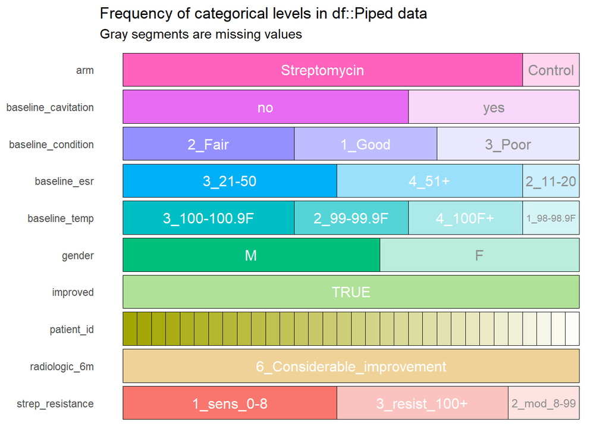

```r
cat_plot_list[["6_Considerable_improvement"]] # "6_Considerable_improvement"
```

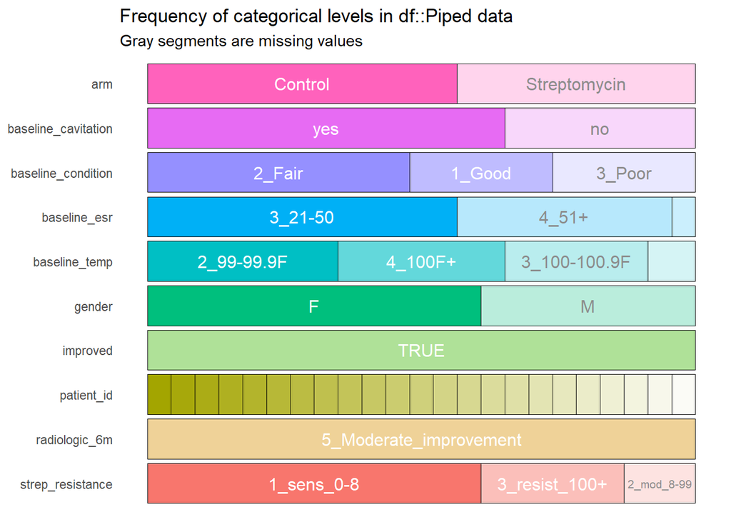

```r
cat_plot_list[["5_Moderate_improvement"]]
```

```r
cat_plot_list[[1]]
```

[output not shown]

‣ To display all plots at once, call the entire list.

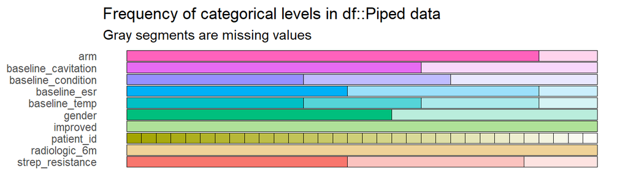

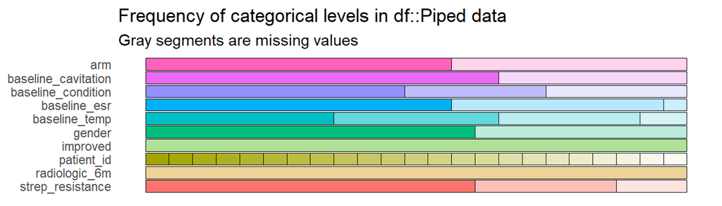

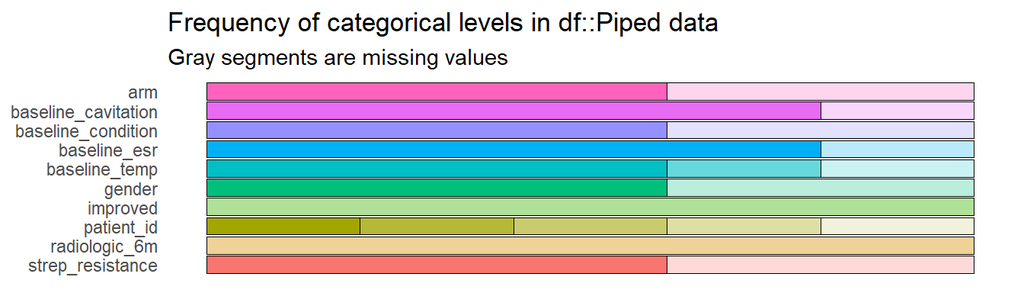

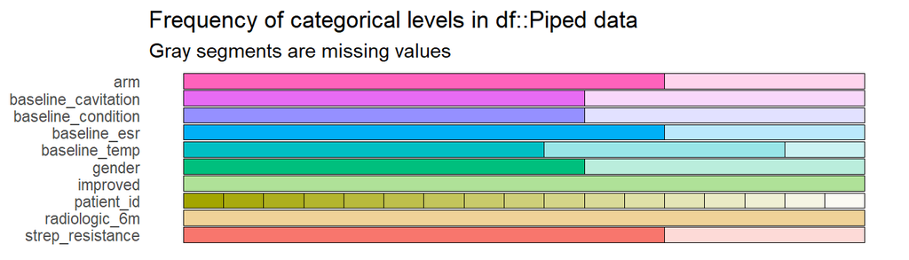

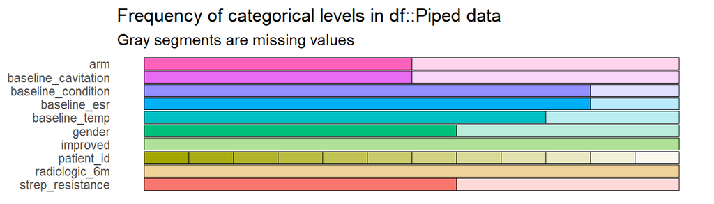

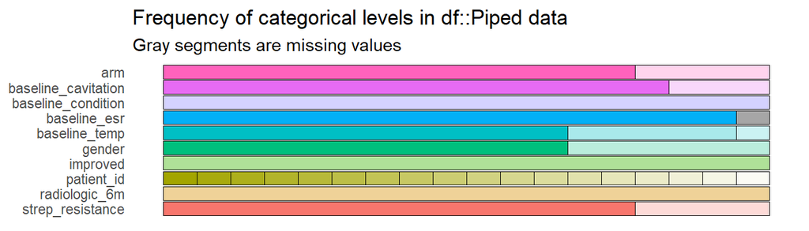

```r
cat_plot_list
```

### Visualizing TB Cases

In this exercise, you will use WHO data from the `tidyr` package to create line graphs showing the number of new TB cases in children over the years in South American countries.

First, we’ll prepare the data:

```r
tb_child_cases <- tidyr::who2 %>%
  transmute(country, year,
            tb_cases_children = sp_m_014 + sp_f_014 + sn_m_014 + sn_f_014) %>%
  filter(country %in% c("Brazil", "Colombia", "Argentina",
                        "Uruguay", "Chile", "Guyana"))  %>%
  filter(year >= 2006)

tb_child_cases
```

```
## # A tibble: 48 × 3
##    country    year tb_cases_children
##    <chr>     <dbl>             <dbl>
##  1 Argentina  2006               880
##  2 Argentina  2007              1162
##  3 Argentina  2008               961
##  4 Argentina  2009               593
##  5 Argentina  2010               491
##  6 Argentina  2011               867
##  7 Argentina  2012               745
##  8 Argentina  2013                NA
##  9 Brazil     2006              2254
## 10 Brazil     2007              2237
## # ℹ 38 more rows
```

Now, fill in the blanks in the template below to create a line graph for each country using a `for` loop:

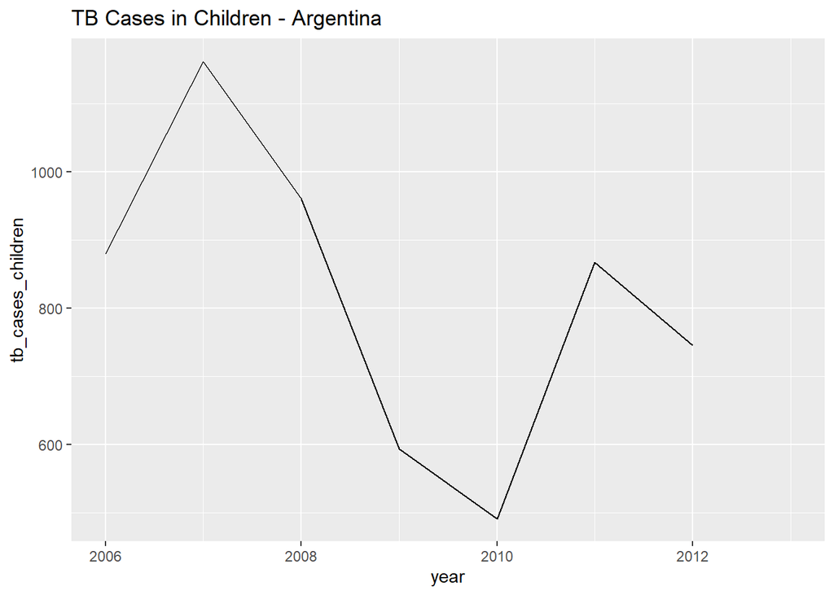

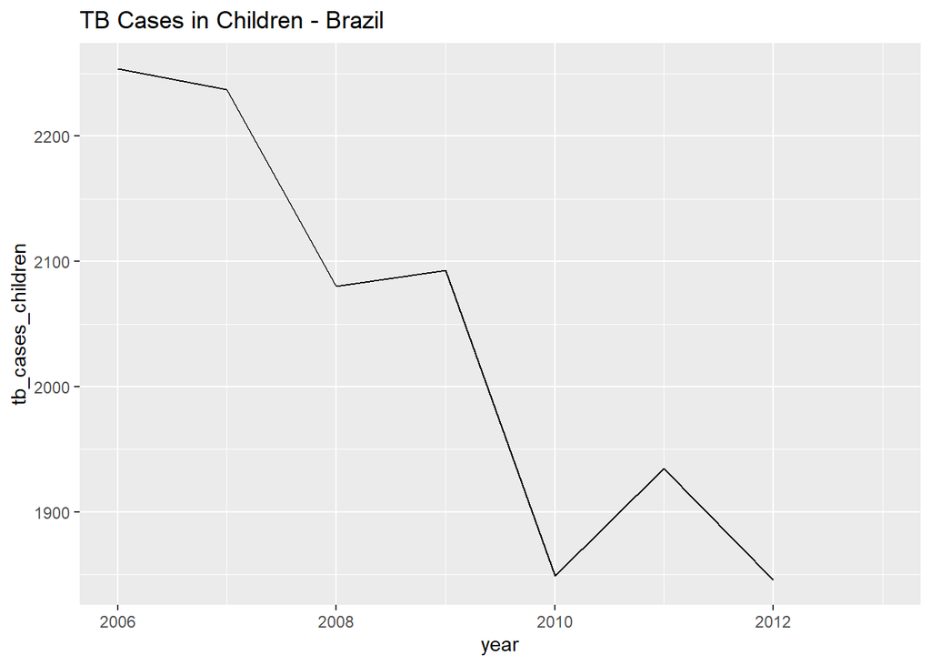

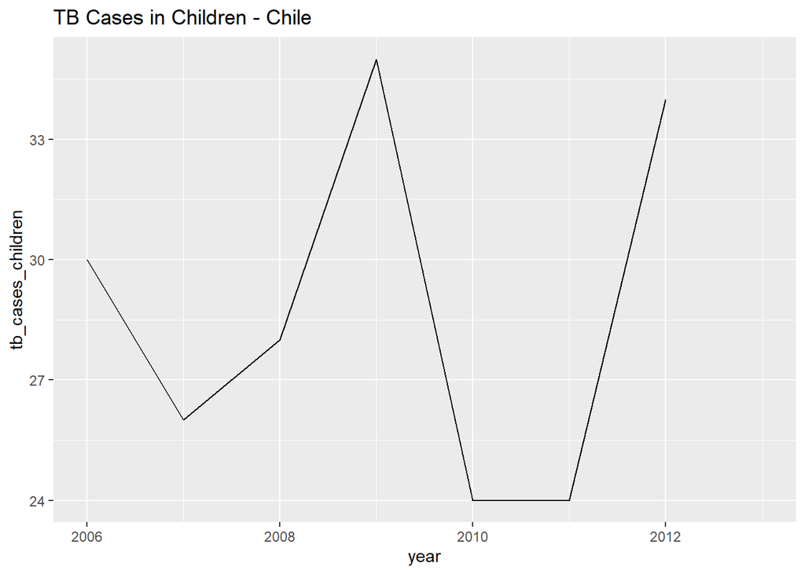

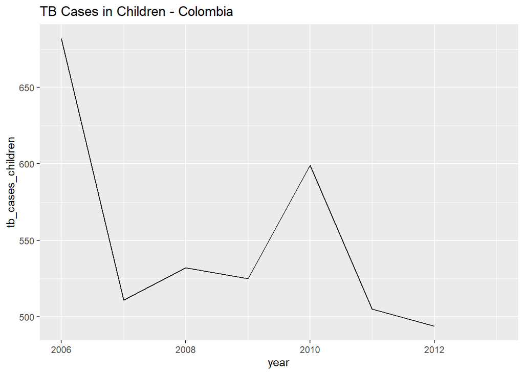

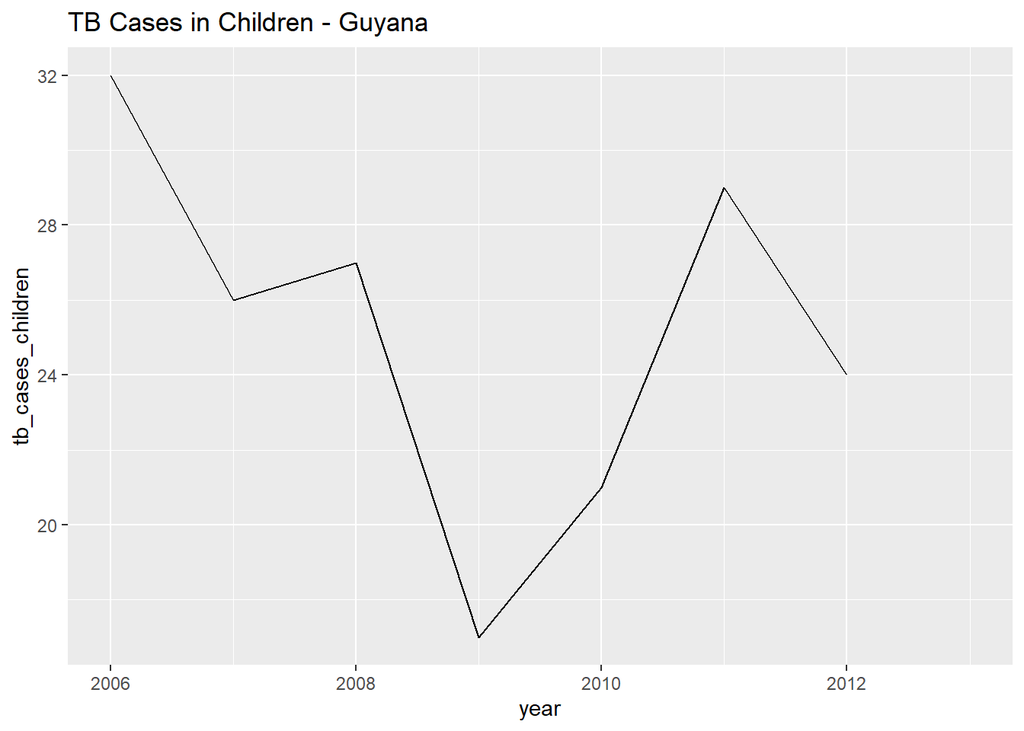

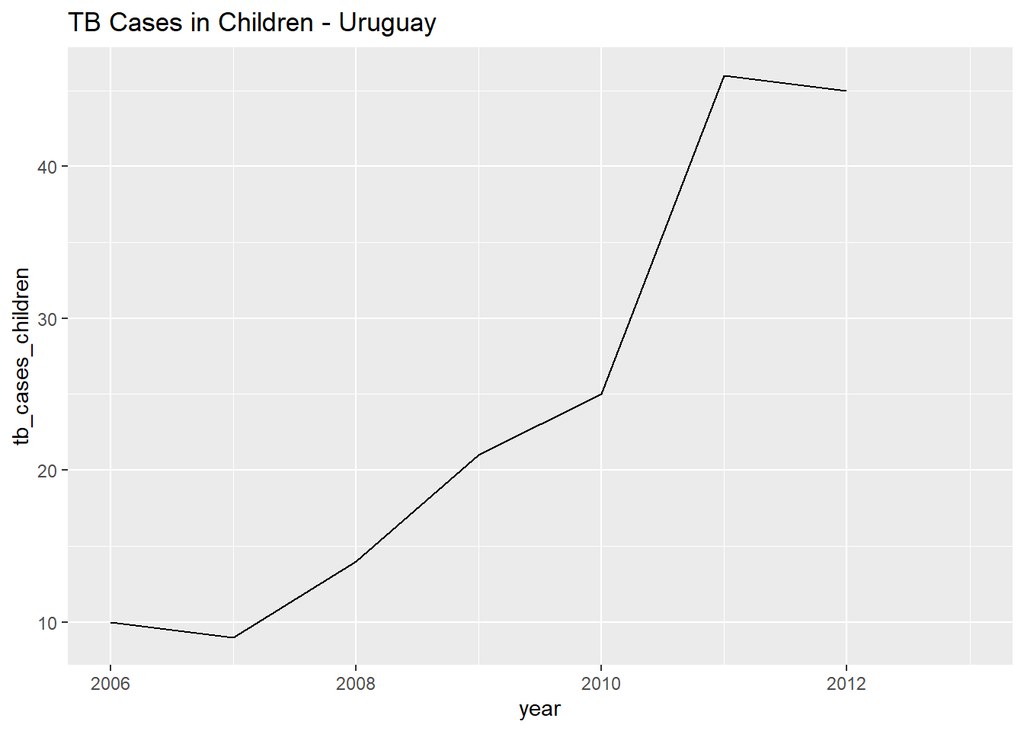

```r
# Get list of countries. Hint: Use unique() on the country column
countries <- unique(tb_child_cases$country)
# Create list to store plots. Hint: Initialize an empty list
tb_child_cases_plots <- vector("list", length(countries))

names(tb_child_cases_plots) <- countries # Set names of list elements

# Loop through countries
for (name in countries) {

  # Filter data for each country
  tb_child_cases_filtered <-  filter(tb_child_cases, country == name)

  # Make plot
  tb_child_cases_plot <- ggplot(tb_child_cases_filtered, aes(x = year, y = tb_cases_children)) +
    geom_line() +
    ggtitle(paste("TB Cases in Children -", name))


  # Append to list. Hint: Use double brackets
  tb_child_cases_plots[[name]] <- tb_child_cases_plot
}

tb_child_cases_plots
```

# 7 Wrap Up!

# 8 Answer Key

### 8.0.1 Hours to Minutes Basic Loop

```r
hours <- c(3, 4, 5) # Vector of hours

for (hour in hours) {
  minutes <- hour * 60
  print(minutes)
}
```

```
## [1] 180
## [1] 240
## [1] 300
```

### 8.0.2 Hours to Minutes Indexed Loop

```r
hours <- c(3, 4, 5) # Vector of hours

for (i in 1:length(hours)) {
  minutes <- hours[i] * 60
  print(minutes)
}
```

```
## [1] 180
## [1] 240
## [1] 300
```

### 8.0.3 BMI Calculation Loop

```r
weights <- c(30, 32, 35) # Weights in kg
heights <- c(1.2, 1.3, 1.4) # Heights in meters

for(i in 1:length(weights)) {
  bmi <- weights[i] / (heights[i] ^ 2)

  print(paste("Weight:", weights[i],
              "Height:", heights[i],
              "BMI:", bmi))
}
```

```
## [1] "Weight: 30 Height: 1.2 BMI: 20.8333333333333"
## [1] "Weight: 32 Height: 1.3 BMI: 18.9349112426035"
## [1] "Weight: 35 Height: 1.4 BMI: 17.8571428571429"
```

### 8.0.4 Height cm to m

```r
height_cm <- c(180, 170, 190, 160, 150) # Heights in cm

height_m <- vector("numeric", length = length(height_cm))

for (i in 1:length(height_cm)) {
  height_m[i] <- height_cm[i] / 100
}
height_m
```

```
## [1] 1.8 1.7 1.9 1.6 1.5
```

### 8.0.5 Temperature Classification

```r
body_temps <- c(35, 36.5, 37, 38, 39.5) # Body temperatures in Celsius
classif_vec <- vector(mode = "character", length = length(body_temps))

for (i in 1:length(body_temps)) {
    if (body_temps[i] < 36.0) {
        classif_vec[i] <- paste(body_temps[i], "°C is Hypothermia")
    } else if (body_temps[i] <= 37.5) {
        classif_vec[i] <- paste(body_temps[i], "°C is Normal")
    } else {
        classif_vec[i] <- paste(body_temps[i], "°C is Fever")
    }
}

classif_vec
```

```
## [1] "35 °C is Hypothermia" "36.5 °C is Normal"    "37 °C is Normal"
## [4] "38 °C is Fever"       "39.5 °C is Fever"
```

### 8.0.6 Visualizing TB Cases

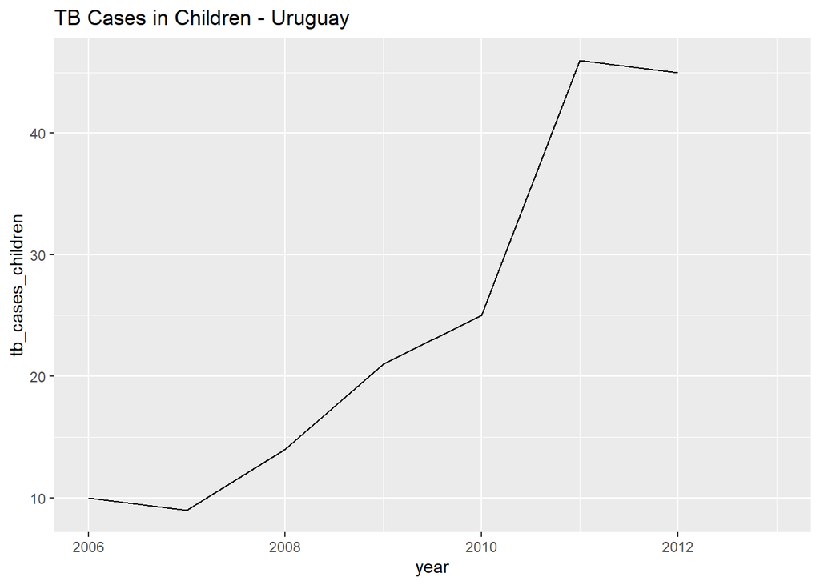

```r
# Assuming tb_child_cases is a dataframe with the necessary columns
countries <- unique(tb_child_cases$country)

# Create list to store plots
tb_child_cases_plots <- vector("list", length(countries))
names(tb_child_cases_plots) <- countries

# Loop through countries
for (countryname in countries) {

  # Filter data for each country
  tb_child_cases_filtered <- filter(tb_child_cases, country == countryname)

  # Make plot
  tb_child_cases_plot <- ggplot(tb_child_cases_filtered, aes(x = year, y = tb_cases_children)) +
    geom_line() +
    ggtitle(paste("TB Cases in Children -", countryname))

  # Append to list
  tb_child_cases_plots[[countryname]] <- tb_child_cases_plot
}

tb_child_cases_plots[["Uruguay"]]
```

# Contributors

The following team members contributed to this lesson:

- [SABINA RODRIGUEZ VELÁSQUEZ](https://thegraphcourses.org/members/sabina/)  
  Project Manager and Scientific Collaborator, The GRAPH Network

  Infectiously enthusiastic about microbes and Global Health
- [KENE DAVID NWOSU](https://thegraphcourses.org/members/kendavidn/)  
  Data analyst, the GRAPH Network

  Passionate about world improvement

# References

Some material in this lesson was adapted from the following sources:

- Barnier, Julien. “Introduction à R et au tidyverse.” https://juba.github.io/tidyverse
- Wickham, Hadley; Grolemund, Garrett. “R for Data Science.” https://r4ds.had.co.nz/
- Wickham, Hadley; Grolemund, Garrett. “R for Data Science (2e).” https://r4ds.hadley.nz/